# re_airquality

Jonathan Lanz 23-106-255

10.03.2025

For this exercise, I investigate the R dataset “airquality”. This dataset contains daily air quality measurements in New York from May to September 1973 and therefore 153 observations. It consists of the following variables: mean daily ozone [ppb]; solar radiation from 8-12am [lan]; mean wind speed from 7-10am [mph]; maximum daily temperature [°F]; month (1-12); day of month (1-31).

The question I want to investigate is: what influence do wind, temperature and solar radiation have on the ozone content in the air?

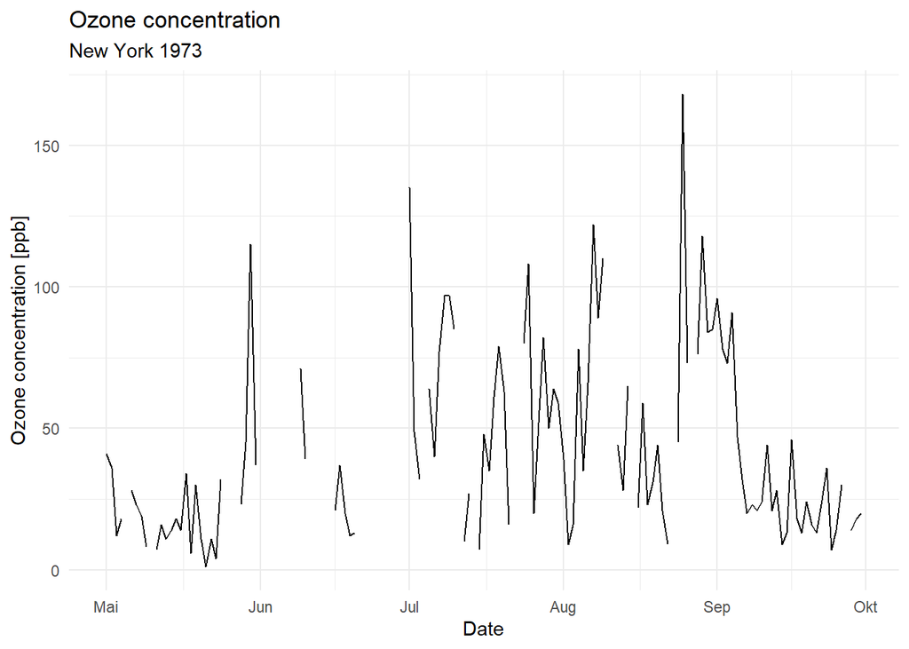

```r
library(tidyverse)
library(ggplot2)
library(readr)
library(lubridate)
library(dplyr)

#plot ozone concentration for each day
airquality <- datasets::airquality |>
  dplyr::mutate(Date = ymd(paste(1973, Month, Day)))

ggplot(data = airquality, aes(x = Date, y = Ozone)) +
  geom_line() +
  labs(title = "Ozone concentration",
       subtitle = "New York 1973",
       x = "Date",
       y = "Ozone concentration [ppb]") +
  theme_minimal()
```

As one can easily spot, the graph is disrupted several times. This is due to missing ozone measurements on the respective days. Note also that the values vary on a rather vast range.

For a broader overview, let’s now look at the monthly means and maxima. To do this, I remove the rows with missing ozone concentration values from the dataset. I will work with the cleaned version in the remainder.

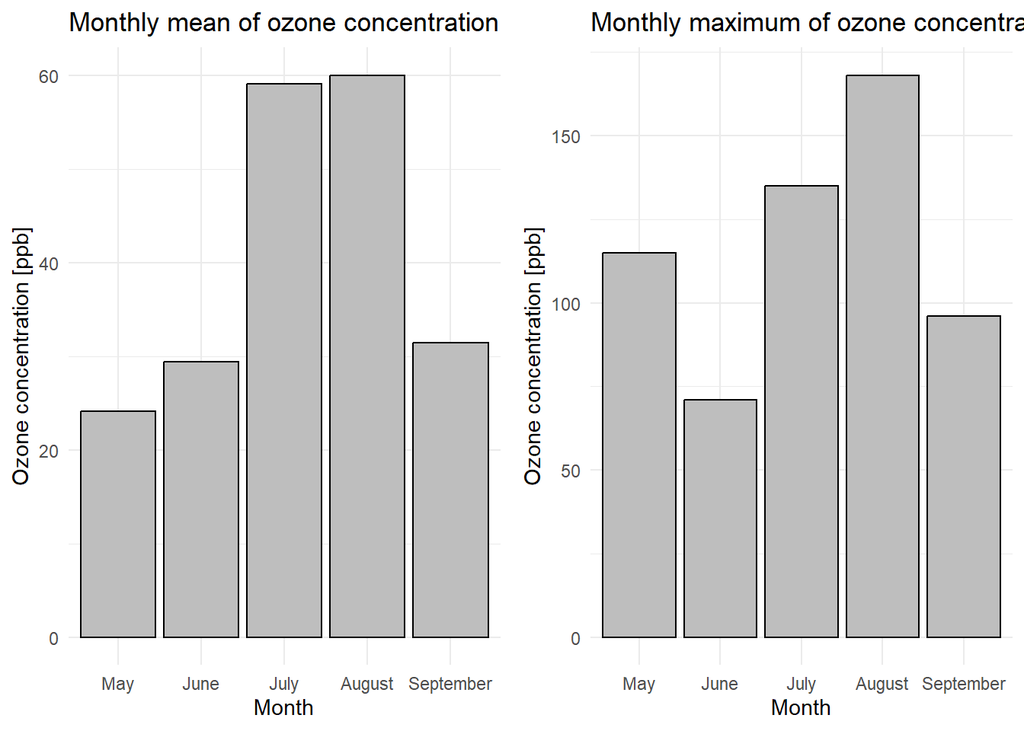

```r
# clean data
airquality_clean <- airquality |> drop_na()

# rename the months
airquality_clean$Month <- factor(month.name[airquality_clean$Month], levels = month.name[5:9], ordered = TRUE)


# calculate monthly means
oz_mean <- ggplot(
  data = airquality_clean |>
    group_by(Month) |>
    summarize(Ozone = mean(Ozone)),
  aes(x = Month, y = Ozone)) +
  geom_bar(stat = "identity", fill = "grey", colour = "black") +
  labs(title = "Monthly mean of ozone concentration",
       x = "Month", y = "Ozone concentration [ppb]") +
  theme_minimal()

# calculate monthly maxima
oz_max <- ggplot(
  data = airquality_clean |>
    group_by(Month) |>
    summarize(Ozone = max(Ozone)),
  aes(x = Month, y = Ozone)) +
  geom_bar(stat = "identity", fill = "grey", colour = "black") +
  labs(title  ="Monthly maximum of ozone concentration",
       x = "Month",
       y = "Ozone concentration [ppb]") +
  theme_minimal()

cowplot::plot_grid(oz_mean, oz_max)
```

The means and maxima have the same trend as the daily measurements: a peak in ozone concentration in July and August. This could potentially indicate a relation between radiation, temperature and wind and ozone content. However, this does not serve as evidence. To address this issue, I calculate the Pearson correlation coefficient.

```r
# search for correlation between ozone and other variables
pearson_rad <- cor(airquality_clean$Ozone, airquality_clean$Solar.R)
pearson_wind <- cor(airquality_clean$Ozone, airquality_clean$Wind)
pearson_temp <- cor(airquality_clean$Ozone, airquality_clean$Temp)


# create a data frame with the results
df_cor <- data.frame(
  cor_oz_rad = pearson_rad,
  cor_oz_wind = pearson_wind,
  cor_oz_temp = pearson_temp
)


# display restults
knitr::kable(df_cor, caption = "Correlation between Ozone and other variables (Pearson)")
```

Correlation between Ozone and other variables (Pearson)

| cor_oz_rad | cor_oz_wind | cor_oz_temp |
| --- | --- | --- |
| 0.3483417 | -0.6124966 | 0.6985414 |

For wind and temperature, the Pearson correlation coeffizient indicates a strong correlation. Double-checking these values with the Spearman correlation coefficient confirms this.

```r
#search for correlation between ozone and other variables
spearman_rad <- cor(airquality_clean$Ozone, airquality_clean$Solar.R, method = "spearman")
spearman_wind <- cor(airquality_clean$Ozone, airquality_clean$Wind, method = "spearman")
spearman_temp <- cor(airquality_clean$Ozone, airquality_clean$Temp, method = "spearman")


#create a data frame with the results
df_cor_sp <- data.frame(
  sp_cor_oz_rad = spearman_rad,
  sp_cor_oz_wind = spearman_wind,
  sp_cor_oz_temp = spearman_temp
)


#display restults
knitr::kable(df_cor_sp, caption = "Correlation between Ozone and other variables (Spearman)")
```

Correlation between Ozone and other variables (Spearman)

| sp_cor_oz_rad | sp_cor_oz_wind | sp_cor_oz_temp |
| --- | --- | --- |
| 0.3481865 | -0.6051364 | 0.7729319 |

To illustrate this, I plot the Ozone concentration against the solar radiation, the wind, and the temperature.

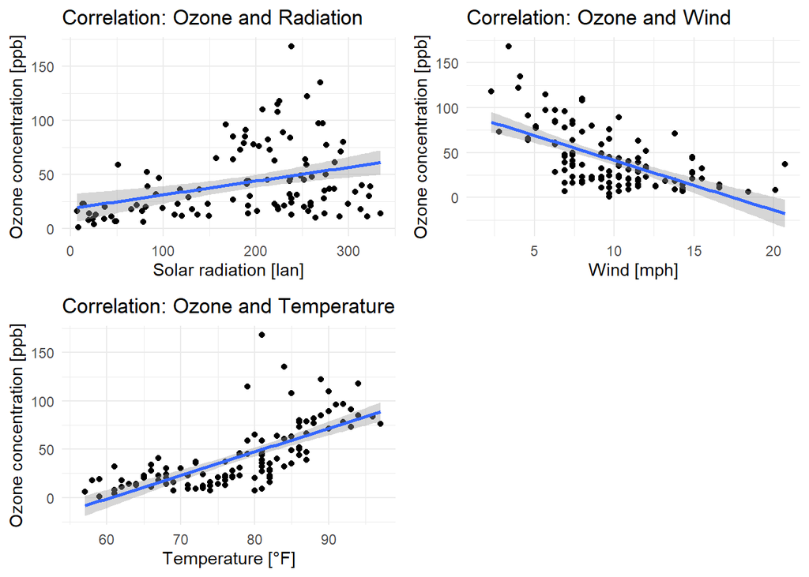

```r
# Generate plots
oz_rad <- ggplot(
  data = airquality,
  aes(x = Solar.R, y = Ozone)) +
  geom_point() +
  geom_smooth(method = "lm") +
  labs(title = "Correlation: Ozone and Radiation",
       x = "Solar radiation [lan]",
       y = "Ozone concentration [ppb]") +
  theme_minimal()

oz_wind <- ggplot(
  data = airquality,
  aes(x = Wind, y = Ozone)) +
  geom_point() +
  geom_smooth(method = "lm") +
  labs(title = "Correlation: Ozone and Wind",
       x = "Wind [mph]",
       y = "Ozone concentration [ppb]") +
  theme_minimal()

oz_temp <- ggplot(
  data = airquality,
  aes(x = Temp, y = Ozone)) +
  geom_point() +
  geom_smooth(method = "lm") +
  labs(title = "Correlation: Ozone and Temperature",
       x = "Temperature [°F]",
       y = "Ozone concentration [ppb]") +
  theme_minimal()

# Combine plots
cowplot::plot_grid(oz_rad, oz_wind, oz_temp)
```

I conclude that while solar radiation has only a weak correlation with it, temperature and wind do have a relation with the ozone content in the air. The temperature has a positive correlation, which means that the ozone concentration rises with rising temperature. The opposite is true for wind - strong wind leads to a decline in ozone concentration.